# Step by step process

Thomas To

23/11/2023

## ETL in SQL (Big Query)

**Extraction and Importing:** Extracted data from [Airbnb](http://insideairbnb.com/get-the-data/), imported into BigQuery, and assessed data loading.

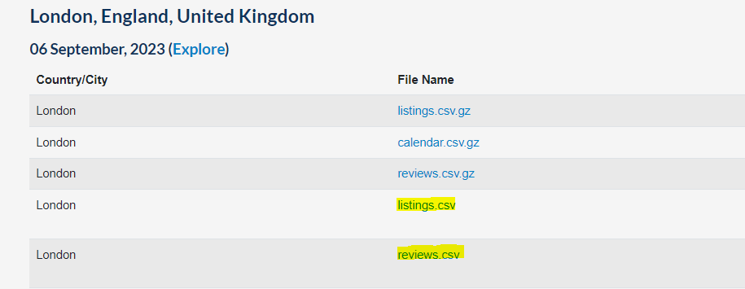

*Data sourced from Airbnb*

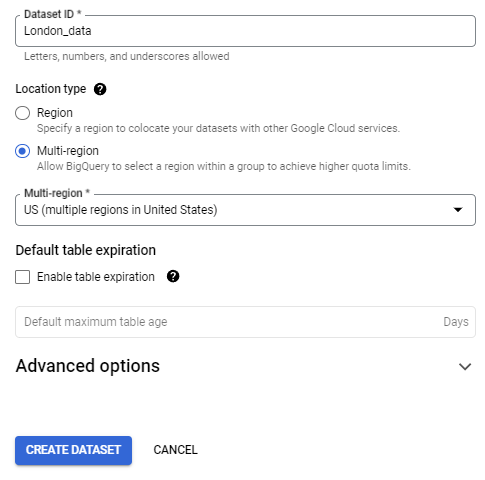

*Creating Data warehouse*

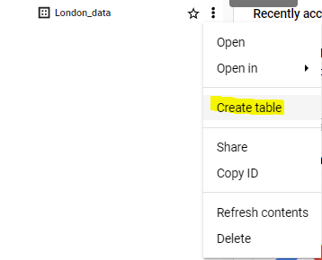

*Importing multiple tables*

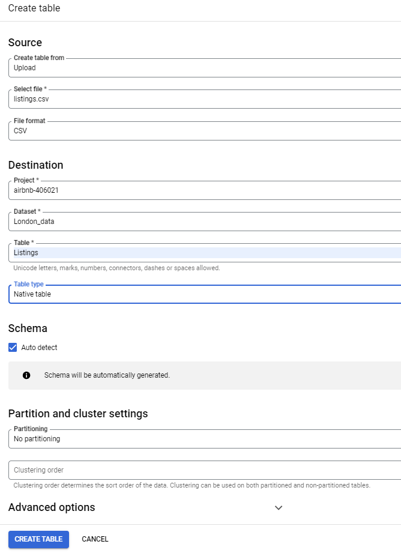

*Configuration for data import*

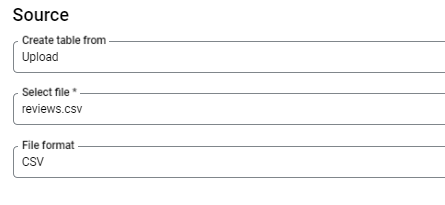

*Import of 2nd data table*

**Handling Missing Values:** Identified missing values in “Last Review date,” used JOIN functions to populate missing data.

**Column Transformation:** Split condensed information in the ‘name’ column into separate values.

**Combining Queries:** Condensed previous queries into a single, efficient query for data processing.

**Exporting Cleaned Data:** Exported the cleaned dataset into a new table within the database.

**Data Type Correction:** Identified issues with the data type in the Rating column and attempted to correct it, handling anomalies like mixing bedroom data into the ratings.

**Refinement of Rating Column:** Updated queries to refine the Rating column, handling ‘New’ values as null. Final Export: Exported the refined data into a new table.

## Visualization with R

**Package Installation:** Installed necessary R packages for data manipulation and visualization.

**Data Manipulation:** Filtered outliers, summarized key insights about total reviews, average price, and availability based on room types and neighborhoods.

**Visual Exploration:** Created visualizations depicting relationships between variables such as room type and reviews, price vs. rating, geographical distribution of listings, etc.

**Geographical Mapping:** Utilized Google Maps API to plot the location of Airbnb listings on a map of London.